# Data 624 Homework 7

Steven Gonzalez

4/6/2025

## Load Packages

```r
library(AppliedPredictiveModeling)
library(caret)
library(corrplot)
library(elasticnet)
library(penalized)
library(pls)
library(grplasso)
library(lars)
library(MASS)
library(stats)
library(tidyverse)
library(VIM)
```

## Exercise 2

Developing a model to predict permeability could save significant resources for a pharmaceutical company, while at the same time more rapidly identifying molecules that have a sufficient permeability to become a drug:

Start R and use these commands to load the data:

```r
data(permeability)
```

The matrix fingerprints contains the 1,107 binary molecular predictors for the 165 compounds, while permeability contains permeability response.

The fingerprint predictors indicate the presence or absence of substructures of a molecule and are often sparse meaning that relatively few of the molecules contain each substructure. Filter out the predictors that have low frequencies using the `nearZeroVar` function from the `caret` package. How many predictors are left for modeling?

```r
str(fingerprints)
```

```
##  num [1:165, 1:1107] 0 0 0 0 0 0 0 0 0 0 ...
##  - attr(*, "dimnames")=List of 2
##   ..$ : chr [1:165] "1" "2" "3" "4" ...
##   ..$ : chr [1:1107] "X1" "X2" "X3" "X4" ...
```

```r
low_freq_preds <- nearZeroVar(fingerprints)
low_freq_preds
```

```
##   [1]    7    8    9   10   13   14   17   18   19   22   23   24   30   31   32
##  [16]   33   34   45   77   81   82   83   84   85   89   90   91   92   95  100
##  [31]  104  105  106  107  109  110  112  113  114  115  116  117  119  120  122
##  [46]  123  124  128  131  132  134  135  136  137  139  140  144  145  147  148
##  [61]  149  151  155  160  161  164  165  166  216  217  218  219  220  222  243
##  [76]  252  259  273  275  277  282  283  287  288  289  292  346  347  348  349
##  [91]  350  351  352  353  354  363  364  365  369  375  379  384  391  393  397
## [106]  399  402  404  405  407  408  409  410  411  412  413  414  415  416  417
## [121]  418  419  420  421  422  423  424  425  426  427  428  429  430  431  432
## [136]  433  434  435  436  437  438  439  440  441  442  443  444  445  446  447
## [151]  448  449  450  451  452  453  454  455  456  457  458  459  460  461  462
## [166]  463  464  465  466  467  468  469  470  471  472  473  474  475  476  477
## [181]  478  479  480  481  482  483  484  485  486  487  488  489  490  491  492
## [196]  493  494  495  498  500  501  502  513  523  525  526  527  528  530  531
## [211]  532  533  534  535  536  537  538  539  540  541  542  543  544  545  546
```

[output cut: 33 more lines]

```r
length(low_freq_preds)
```

```
## [1] 719
```

```r
fp_filtered <- fingerprints[,-low_freq_preds]
str(fp_filtered)
```

```
##  num [1:165, 1:388] 0 0 0 0 0 0 0 0 0 0 ...
##  - attr(*, "dimnames")=List of 2
##   ..$ : chr [1:165] "1" "2" "3" "4" ...
##   ..$ : chr [1:388] "X1" "X2" "X3" "X4" ...
```

As can be seen from the results above, 719 of the predictors had low frequencies and were thus filtered out. Leaving us with 388 predictors for modeling.

Split the data into a training and a test set, pre-process the data, and tune a PLS model. How many latent variables are optimal and what is the corresponding resampled estimate of R^2?

```r
set.seed(71)
split <- permeability %>%
  createDataPartition(p = 0.8, list = FALSE, times = 1)

Xtrain.data  <- fp_filtered[split, ]
xtest.data <- fp_filtered[-split, ]


Ytrain.data  <- permeability[split, ]
ytest.data <- permeability[-split, ]

ctrl <- trainControl(method = "cv", number = 10)
pls_model <- train(x = Xtrain.data,
                   y = Ytrain.data,
                   method = "pls",
                   tuneLength = 20,
                   trControl = ctrl,
                   preProc = c("center", "scale"))
pls_model
```

```
## Partial Least Squares
##
## 133 samples
## 388 predictors
##
## Pre-processing: centered (388), scaled (388)
## Resampling: Cross-Validated (10 fold)
## Summary of sample sizes: 120, 119, 120, 120, 120, 120, ...
## Resampling results across tuning parameters:
##
##   ncomp  RMSE      Rsquared   MAE
##    1     13.40963  0.3566085  10.300982
##    2     12.03158  0.4983520   8.531048
##    3     11.98115  0.5306144   8.919622
##    4     11.77743  0.5214277   8.807726
##    5     11.56287  0.5194512   8.436684
##    6     11.30635  0.5199872   8.170254
##    7     11.33887  0.5198030   8.487785
##    8     11.73040  0.5018390   8.799399
##    9     12.06584  0.4859098   9.050962
##   10     12.16738  0.4847391   9.087767
##   11     12.30778  0.4840229   9.145742
##   12     12.73094  0.4729775   9.366431
##   13     12.90488  0.4649557   9.620829
##   14     13.09871  0.4533665   9.788464
##   15     13.36499  0.4410856   9.946836
##   16     13.81829  0.4124786  10.205286
##   17     14.16176  0.3989711  10.373191
##   18     14.27418  0.3914947  10.387093
##   19     14.55635  0.3824931  10.688243
##   20     14.64989  0.3787505  10.834724
##
## RMSE was used to select the optimal model using the smallest value.
## The final value used for the model was ncomp = 6.
```

As can be seen in the results above, anywhere from 3 to 6 components could prove optimal. A number of 3 components gives us our highest value for R^2, 0.5306144, and a number of 6 components leads to our lowest values of RMSE and MAE, 11.30635 and 8.170254, respectively.

Predict the response for the test set. What is the test set estimate of R^2?

```r
pls_prediction <- pls_model %>%
  predict(xtest.data)

cbind(
  RMSE = RMSE(pls_prediction, ytest.data),
  "R^2" = caret::R2(pls_prediction, ytest.data)
)
```

```
##          RMSE       R^2
## [1,] 12.94361 0.2213123
```

The test set estimate of R^2 is 0.2213123.

Try building other models discussed in this chapter. Do any have better predictive performance?

```r
set.seed(72)
linear_model <- train(x = Xtrain.data,
                      y = Ytrain.data,
                      method = "lm",
                      trControl = ctrl)

linear_prediction <- linear_model %>%
  predict(xtest.data)

cbind(RMSE = RMSE(linear_prediction, ytest.data),
      "R^2" = caret::R2(linear_prediction, ytest.data))
```

```
##          RMSE        R^2
## [1,] 22.85912 0.06861545
```

```r
set.seed(73)
ridge_grid <- data.frame(.lambda = seq(0.001, 0.5, length = 25))
ridge_model <- train(x = Xtrain.data,
                     y = Ytrain.data,
                     method = "ridge",
                     metric = "Rsquared",
                     tuneGrid = ridge_grid,
                     trControl = ctrl,
                     preProc = c("center", "scale"))

ridge_prediction <- ridge_model %>%
  predict(xtest.data)

cbind(RMSE = RMSE(ridge_prediction, ytest.data),
      "R^2" = caret::R2(ridge_prediction, ytest.data))
```

```
##          RMSE       R^2
## [1,] 13.29316 0.3486511
```

Would you recommend any of your models to replace the permeability laboratory experiment?

## Exercise 3

A chemical manufacturing process for a pharmaceutical product was discussed in Sect. 1.4. In this problem, the objective is the understand the relationship between biological measurements of the raw materials (predictors), measurements of the manufacturing process (predictors), and the response of product yield. Biological predictors cannot be changed but can be used to assess the quality of the raw material before processing. On the other hand, manufacturing process predictors can be changed in the manufacturing process. Improving product yield by 1 % will boost revenue by approximately one hundred thousand dollars per batch.

Start R and use these commands to load the data:

```r
data(ChemicalManufacturingProcess)
str(ChemicalManufacturingProcess)
```

```
## 'data.frame':    176 obs. of  58 variables:
##  $ Yield                 : num  38 42.4 42 41.4 42.5 ...
##  $ BiologicalMaterial01  : num  6.25 8.01 8.01 8.01 7.47 6.12 7.48 6.94 6.94 6.94 ...
##  $ BiologicalMaterial02  : num  49.6 61 61 61 63.3 ...
##  $ BiologicalMaterial03  : num  57 67.5 67.5 67.5 72.2 ...
##  $ BiologicalMaterial04  : num  12.7 14.6 14.6 14.6 14 ...
##  $ BiologicalMaterial05  : num  19.5 19.4 19.4 19.4 17.9 ...
##  $ BiologicalMaterial06  : num  43.7 53.1 53.1 53.1 54.7 ...
##  $ BiologicalMaterial07  : num  100 100 100 100 100 100 100 100 100 100 ...
##  $ BiologicalMaterial08  : num  16.7 19 19 19 18.2 ...
##  $ BiologicalMaterial09  : num  11.4 12.6 12.6 12.6 12.8 ...
##  $ BiologicalMaterial10  : num  3.46 3.46 3.46 3.46 3.05 3.78 3.04 3.85 3.85 3.85 ...
##  $ BiologicalMaterial11  : num  138 154 154 154 148 ...
##  $ BiologicalMaterial12  : num  18.8 21.1 21.1 21.1 21.1 ...
##  $ ManufacturingProcess01: num  NA 0 0 0 10.7 12 11.5 12 12 12 ...
```

[output cut: 44 more lines]

The matrix processPredictors contains the 57 predictors (12 describing the input biological material and 45 describing the process predictors) for the 176 manufacturing runs. yield contains the percent yield for each run.

A small percentage of cells in the predictor set contain missing values. Use an imputation function to fill in these missing values.

```r
sum(is.na(ChemicalManufacturingProcess))
```

```
## [1] 106
```

```r
ChemicalManufacturingProcess %>%
  summarize_all(funs(sum(is.na(.)))) %>%
  pivot_longer(everything(),
               names_to = 'Predictor',
               values_to = 'Number of Missing Values')
```

```
## # A tibble: 58 × 2
##    Predictor            `Number of Missing Values`
##    <chr>                                     <int>
##  1 Yield                                         0
##  2 BiologicalMaterial01                          0
##  3 BiologicalMaterial02                          0
##  4 BiologicalMaterial03                          0
##  5 BiologicalMaterial04                          0
##  6 BiologicalMaterial05                          0
##  7 BiologicalMaterial06                          0
##  8 BiologicalMaterial07                          0
##  9 BiologicalMaterial08                          0
## 10 BiologicalMaterial09                          0
## # ℹ 48 more rows
```

```r
cmp_imputed <- kNN(ChemicalManufacturingProcess, k = 5) %>%
  select(c(1:58))

sum(is.na(cmp_imputed))
```

```
## [1] 0
```

```r
cmp_imputed %>%
  summarize_all(funs(sum(is.na(.)))) %>%
  pivot_longer(everything(),
               names_to = 'Predictor',
               values_to = 'Number of Missing Values')
```

```
## # A tibble: 58 × 2
##    Predictor            `Number of Missing Values`
##    <chr>                                     <int>
##  1 Yield                                         0
##  2 BiologicalMaterial01                          0
##  3 BiologicalMaterial02                          0
##  4 BiologicalMaterial03                          0
##  5 BiologicalMaterial04                          0
##  6 BiologicalMaterial05                          0
##  7 BiologicalMaterial06                          0
##  8 BiologicalMaterial07                          0
##  9 BiologicalMaterial08                          0
## 10 BiologicalMaterial09                          0
## # ℹ 48 more rows
```

Split the data into a training and a test set, pre-process the data, and tune a model of your choice from this chapter. What is the optimal value of the performance metric?

```r
cmp_prepared <- cmp_imputed %>%
  select(!nearZeroVar(.))

set.seed(74)
split1 <- createDataPartition(cmp_prepared$Yield, p = 0.8, list = FALSE)

train.data  <- cmp_prepared[split1, ]
test.data <- cmp_prepared[-split1, ]

ctrl1 <- trainControl(method = "cv", number = 10)

ridge_grid1 <- data.frame(.lambda = seq(0.001, 0.5, length = 25))
ridge_model1 <- train(Yield ~ .,
                     data = train.data,
                     method = "ridge",
                     metric = "Rsquared",
                     tuneGrid = ridge_grid1,
                     trControl = ctrl1,
                     preProc = c("center", "scale"))

ridge_model1$results[ridge_model1$results$RMSE == min(ridge_model1$results$RMSE),]
```

```
##       lambda     RMSE Rsquared      MAE   RMSESD RsquaredSD     MAESD
## 12 0.2297083 1.697949 0.500405 1.178778 0.940023  0.2332219 0.4508482
```

Predict the response for the test set. What is the value of the performance metric and how does this compare with the resampled performance metric on the training set?

```r
postResample(pred = predict(ridge_model1, test.data), obs =test.data$Yield)
```

```
##      RMSE  Rsquared       MAE
## 1.4486942 0.6122705 1.1432855
```

Predicting the response for the test set using our ridge model renders the above values for the performance metrics. The RMSE, R^2, and MAE have values of 1.4486942, 0.6122705, and 1.1432855, respectively. Compared to the resampled performance metrics on the training set, it seems to have done better with lower error rate and a higher R^2.

Which predictors are most important in the model you have trained? Do either the biological or process predictors dominate the list?

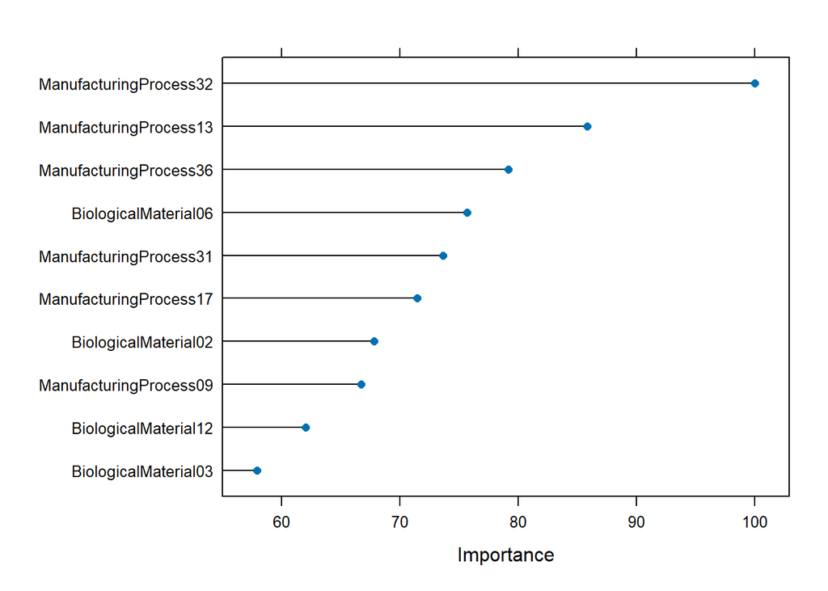

```r
plot(varImp(ridge_model1), top = 10)
```

Above is a plot illustrating the predictors which are most important in the previous ridge model I’ve trained. As can be seen, the process predictors dominate the list.

Explore the relationships between each of the top predictors and the response. How could this information be helpful in improving yield in future runs of the manufacturing process?

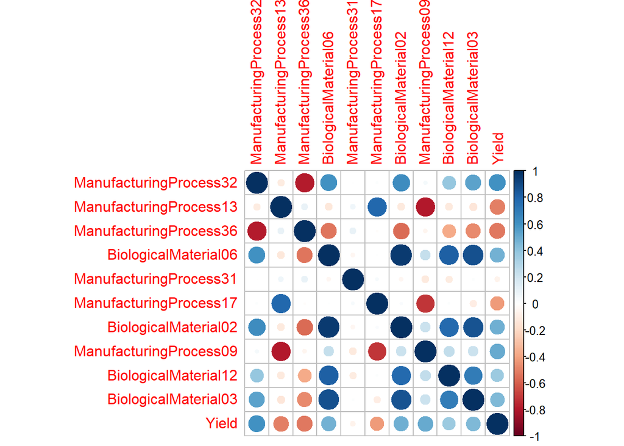

```r
cmp_cor <- cor(cmp_prepared %>%
                       select(ManufacturingProcess32, ManufacturingProcess13,
                              ManufacturingProcess36, BiologicalMaterial06,
                              ManufacturingProcess31, ManufacturingProcess17,
                              BiologicalMaterial02, ManufacturingProcess09,
                              BiologicalMaterial12, BiologicalMaterial03,
                              Yield))
corrplot::corrplot(cmp_cor)
```

Strictly with regards to the response, or yield given the predictor, this information could be helpful in improving yield in future runs of the manufacturing process by pouring more time and resources into the processes which have a higher correlation with yield, meaning that these predictors lead to higher outcome. When it comes to inter-predictor relationships, identifying which variables have high correlations to each other could indicate the need for removal in order to optimize resources.